# Does Sleep Causally affect Stress?

CME Assignment II

Rishabh Patil | 2021A7PS0464H

```r
library(readr)
```

# 1 Research Question

*Primary question:* Does Sleep Stress Levels of Students? We will study the data collected from various volunteers and analyze the causal relation between sleep an stress.

*Hypothesis:* Lower hours of sleep and lower sleep quality leads to high stress levels.

The data we use has:

1. Anxiety Level (GAD-7)
2. Self Esteem (Rosenberg Self Esteem Scale)
3. Mental Health History (0-1)
4. Depression(in accordance with PHQ-9)
5. Headache
6. *Sleep Quality* [treatment 1]
7. Basic Needs
8. Blood Pressure(low)
9. Academic Performance
10. Study Load
11. Teacher Student Relationship
12. Future Career Concerns
13. Extra Cirricular Activities
14. Bullying
15. **Stress Level** outcome[]

## 1.1 What does science say about the correlation of sleep and stress?

Not getting enough sleep can cause a negative mood, low energy, difficulty concentrating, and a general inability to function as usual. Lack of sleep may have severe consequences in some circumstances, such as if a person is driving or operating heavy machinery when tired. The occasional night of poor sleep is unlikely to cause harm, but persistent sleep deprivation can increase the risk of several chronic health conditions.[[1](https://www.medicalnewstoday.com/articles/322994#reducing-stress)]

Research suggests that the relationship between sleep and mental health is complex. While lack of sleep has long been known to be a consequence of many psychiatric conditions, more recent views suggest that lack of sleep can also play a causal role in both the development and maintenance of different mental health problems.[[2](https://www.verywellmind.com/how-sleep-affects-mental-health-4783067)]

# 2 DAG Analysis

From our data-set:

```r
ssdata <- read_csv("R:/Sem V/Comp Methods For Econ/Assignment-II/Data/Sleep_health_and_lifestyle_dataset.csv")
colnames(ssdata)<-tolower(gsub(" ","_",colnames(ssdata)))
head(ssdata)
```

[output not shown]

## 2.1 Deciding the DAG edges

```r
library(dagitty)
library(ggdag)
library(ggplot2)

dag<-dagify(
  STRESS ~ ANXIETY + SELF_ESTEEM + DEPRESSION + HEADACHE + SLEEP_QUALITY + BASIC_NEEDS + STUDY_LOAD + TEACHER_STUDENT_RELATION + FUTURE_CAREER_CONCERNS + BULLYING +LIVING_CONDITIONS,
  SLEEP_QUALITY ~ ANXIETY + HEADACHE + STUDY_LOAD + EXTRACIRRICULAR,
  ANXIETY ~ SELF_ESTEEM + MENTAL_HEALTH_HISTORY  + BULLYING,
  DEPRESSION ~ MENTAL_HEALTH_HISTORY+ACADEMIC_PERFORMANCE + STUDY_LOAD + FUTURE_CAREER_CONCERNS + BULLYING,
  ACADEMIC_PERFORMANCE ~ STUDY_LOAD+TEACHER_STUDENT_RELATION,

  exposure = "SLEEP_QUALITY",
  outcome = "STRESS",
  labels = c(STRESS="STRESS",
           ANXIETY="ANXIETY",
           SELF_ESTEEM="SELF_ESTEEM",
           MENTAL_HEALTH_HISTORY="MENTAL_HEALTH_HISTORY",
           DEPRESSION="DEPRESSION",
           HEADACHE="HEADACHE",
           SLEEP_QUALITY="SLEEP_QUALITY",
           BASIC_NEEDS="BASIC_NEEDS",
           ACADEMIC_PERFORMANCE="ACADEMIC_PERFORMANCE",
           STUDY_LOAD="STUDY_LOAD",
           TEACHER_STUDENT_RELATION="TEACHER_STUDENT_RELATION",
           FUTURE_CAREER_CONCERNS="FUTURE_CAREER_CONCERNS",
           EXTRACIRRICULAR="EXTRACIRRICULAR",
           BULLYING="BULLYING",
           LIVING_CONDITIONS="LIVING_CONDITIONS"
           )
)
```

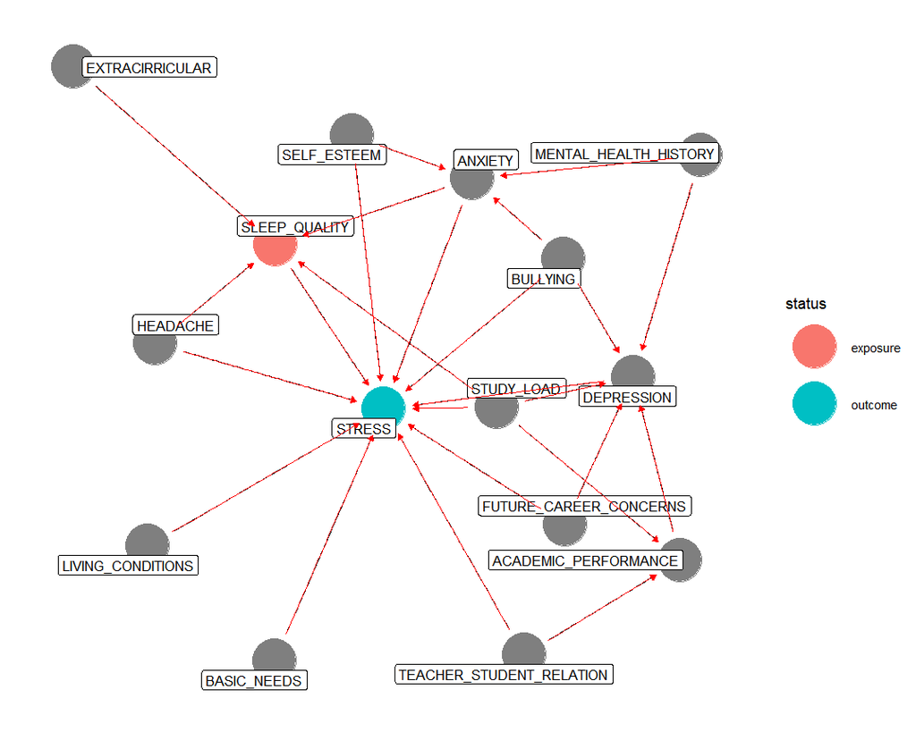

```r
ggdag_status(dag,text = FALSE)+
  geom_dag_label_repel(aes(label = label), colour = "black", show.legend = FALSE)+
  geom_dag_edges_arc(edge_color = "red", curvature = 0) +
  theme_dag()
```

The backdoors are:(confounders)

```r
adjustmentSets(dag)
```

[output not shown]

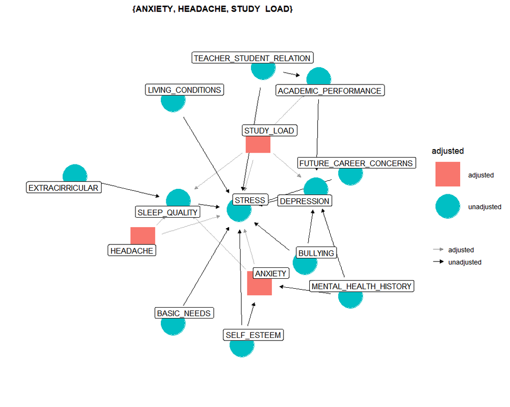

```r
ggdag_adjustment_set(dag,shadow = TRUE,text=FALSE) + geom_dag_label_repel(aes(label = label), colour = "black", show.legend = FALSE)+theme_dag()
```

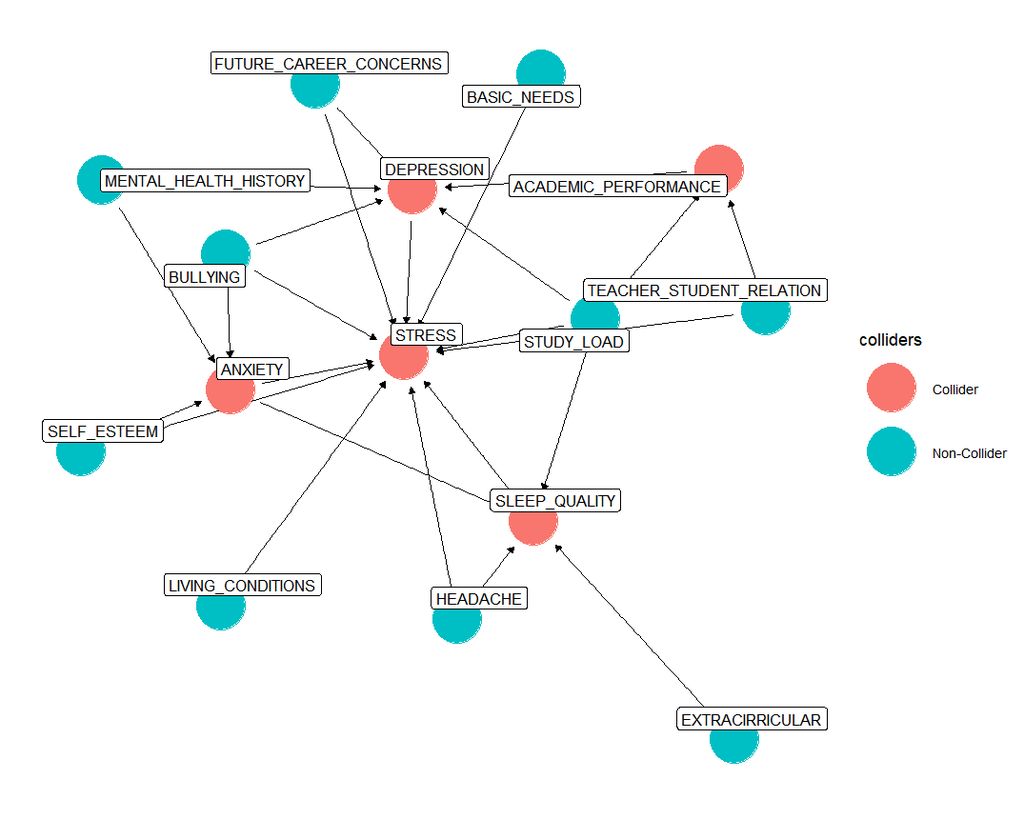

```r
ggdag_collider(dag,text=FALSE) + geom_dag_label_repel(aes(label = label), colour = "black", show.legend = FALSE)+theme_dag()
```

# 3 Checking the distribution of covariates for control and Treatment

To check for the effects of Sleep duration on stress, we need to set some thresholds on sleep duration.

```r
print(mean(ssdata$sleep_quality))
```

```
[1] 2.66
```

```r
print(median(ssdata$sleep_quality))
```

```
[1] 2.5
```

## 3.1 t-test for covariates and outcome:

The p-value estimates for the covariates in the whole data set are:

1. Self Esteem:

```r
print(t.test(ssdata$self_esteem[ssdata$sleep_quality>2.5],ssdata$self_esteem[ssdata$sleep_quality<=2.5])$p.value)
```

```
[1] 1.93977e-99
```

2. Basic Needs:

```r
print(t.test(ssdata$basic_needs[ssdata$sleep_quality>2.5],ssdata$basic_needs[ssdata$sleep_quality<=2.5])$p.value)
```

```
[1] 1.05511e-86
```

3. Future Career Concerns:

```r
print(t.test(ssdata$future_career_concerns[ssdata$sleep_quality>2.5],ssdata$future_career_concerns[ssdata$sleep_quality<=2.5])$p.value)
```

```
[1] 3.095655e-118
```

4. BUllying:

```r
print(t.test(ssdata$bullying[ssdata$sleep_quality>2.5],ssdata$bullying[ssdata$sleep_quality<=2.5])$p.value)
```

```
[1] 4.708424e-119
```

5. Living Conditions

```r
print(t.test(ssdata$living_conditions[ssdata$sleep_quality>2.5],ssdata$living_conditions[ssdata$sleep_quality<=2.5])$p.value)
```

```
[1] 2.884276e-57
```

## 3.2 Plotting the results:

**Factoring the treatment**

```r
ssdata$sleep_quality_treatment<-ifelse(ssdata$sleep_quality>2.5,1,0)
```

Plots:

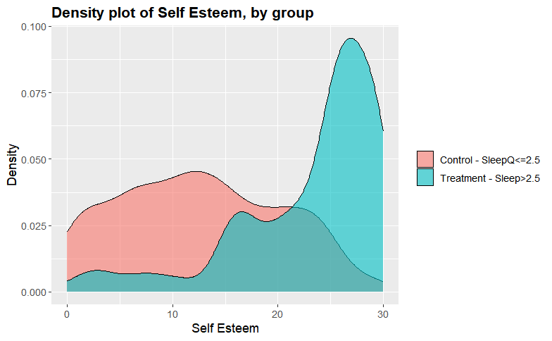

```r
ggplot(ssdata, aes(x = ssdata$self_esteem, fill = factor(ssdata$sleep_quality_treatment))) + geom_density(position="identity", alpha=0.6) +
    scale_fill_brewer(palette="Dark2") + ggtitle("Density plot of Self Esteem, by group") +
    scale_x_continuous(name = "Self Esteem") +
    scale_y_continuous(name = "Density") + theme(plot.title = element_text(size = 14, face =
                                                                               "bold"), text = element_text(size = 12)) + guides(fill=guide_legend(title=NULL))+
    scale_fill_discrete(labels=c("Control - SleepQ<=2.5", "Treatment - Sleep>2.5"))
```

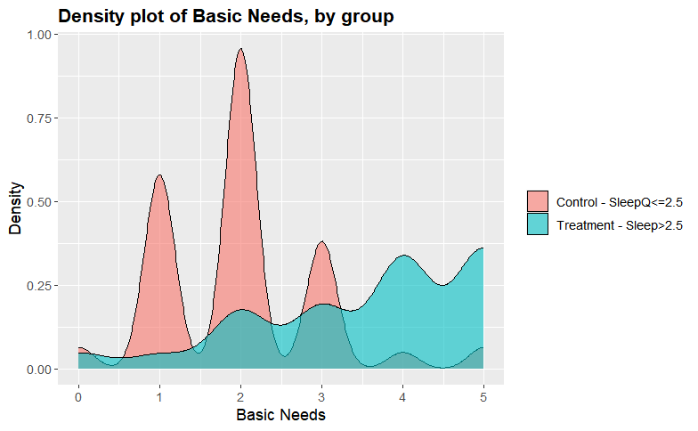

```r
ggplot(ssdata, aes(x = ssdata$basic_needs, fill = factor(ssdata$sleep_quality_treatment))) + geom_density(position="identity", alpha=0.6) +
    scale_fill_brewer(palette="Dark2") + ggtitle("Density plot of Basic Needs, by group") +
    scale_x_continuous(name = "Basic Needs") +
    scale_y_continuous(name = "Density") + theme(plot.title = element_text(size = 14, face =
                                                                               "bold"), text = element_text(size = 12)) + guides(fill=guide_legend(title=NULL))+
    scale_fill_discrete(labels=c("Control - SleepQ<=2.5", "Treatment - Sleep>2.5"))
```

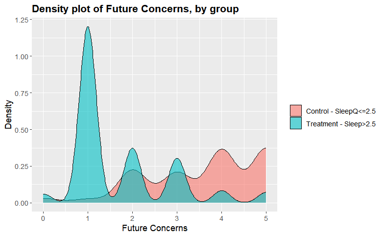

```r
ggplot(ssdata, aes(x = ssdata$future_career_concerns, fill = factor(ssdata$sleep_quality_treatment))) + geom_density(position="identity", alpha=0.6) +
    scale_fill_brewer(palette="Dark2") + ggtitle("Density plot of Future Concerns, by group") +
    scale_x_continuous(name = "Future Concerns") +
    scale_y_continuous(name = "Density") + theme(plot.title = element_text(size = 14, face =
                                                                               "bold"), text = element_text(size = 12)) + guides(fill=guide_legend(title=NULL))+
    scale_fill_discrete(labels=c("Control - SleepQ<=2.5", "Treatment - Sleep>2.5"))
```

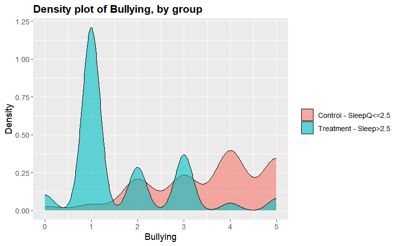

```r
ggplot(ssdata, aes(x = ssdata$bullying, fill = factor(ssdata$sleep_quality_treatment))) + geom_density(position="identity", alpha=0.6) +
    scale_fill_brewer(palette="Dark2") + ggtitle("Density plot of Bullying, by group") +
    scale_x_continuous(name = "Bullying") +
    scale_y_continuous(name = "Density") + theme(plot.title = element_text(size = 14, face =
                                                                               "bold"), text = element_text(size = 12)) + guides(fill=guide_legend(title=NULL))+
    scale_fill_discrete(labels=c("Control - SleepQ<=2.5", "Treatment - Sleep>2.5"))
```

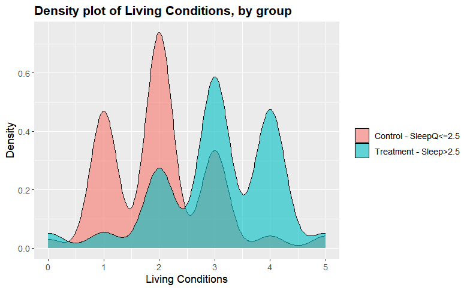

```r
ggplot(ssdata, aes(x = ssdata$living_conditions, fill = factor(ssdata$sleep_quality_treatment))) + geom_density(position="identity", alpha=0.6) +
    scale_fill_brewer(palette="Dark2") + ggtitle("Density plot of Living Conditions, by group") +
    scale_x_continuous(name = "Living Conditions") +
    scale_y_continuous(name = "Density") + theme(plot.title = element_text(size = 14, face =
                                                                               "bold"), text = element_text(size = 12)) + guides(fill=guide_legend(title=NULL))+
    scale_fill_discrete(labels=c("Control - SleepQ<=2.5", "Treatment - Sleep>2.5"))
```

*Findings:* We find that there is a variation in covariates which needs to be mathced in order to properly uncerstand the causal effect of treatment on the outcome.(extremely low p-values)

# 4 Matching

```r
formula<-sleep_quality_treatment ~ self_esteem + basic_needs + future_career_concerns + bullying + living_conditions
```

```r
regmodel<- glm(sleep_quality_treatment ~ self_esteem + basic_needs + future_career_concerns + bullying + living_conditions,data=ssdata,family="binomial")
ssdata$propscore<-predict(regmodel,newdata=ssdata,type="response")
head(ssdata$propscore)
```

```
         1          2          3          4          5          6
0.52732347 0.03377340 0.58377955 0.07231744 0.39368141 0.03946239
```

## 4.1 Nearest Neighbour:(without replacement)

```r
library(MatchIt)
m_without_replacement = matchit(sleep_quality_treatment ~ self_esteem + basic_needs + future_career_concerns + bullying + living_conditions, method = "nearest", data = ssdata)
m_without_replacement_df<-match.data(m_without_replacement)
summary(m_without_replacement)
```

```
Call:
matchit(formula = sleep_quality_treatment ~ self_esteem + basic_needs +
    future_career_concerns + bullying + living_conditions, data = ssdata,
    method = "nearest")

Summary of Balance for All Data:
                       Means Treated Means Control Std. Mean Diff. Var. Ratio eCDF Mean eCDF Max
distance                      0.7351        0.2649          1.8290     0.9994    0.4237   0.5673
self_esteem                  22.9564       12.5982          1.4893     0.8334    0.3341   0.5436
basic_needs                   3.5618        1.9836          1.1415     1.9994    0.2667   0.5491
future_career_concerns        1.6982        3.6000         -1.7242     0.7356    0.3170   0.5545
bullying                      1.6636        3.5709         -1.6881     0.8011    0.3179   0.5709
living_conditions             3.0273        2.0091          0.9719     1.2324    0.1752   0.4927

Summary of Balance for Matched Data:
                       Means Treated Means Control Std. Mean Diff. Var. Ratio eCDF Mean eCDF Max
distance                      0.7351        0.2649          1.8290     0.9994    0.4237   0.5673
self_esteem                  22.9564       12.5982          1.4893     0.8334    0.3341   0.5436
basic_needs                   3.5618        1.9836          1.1415     1.9994    0.2667   0.5491
future_career_concerns        1.6982        3.6000         -1.7242     0.7356    0.3170   0.5545
bullying                      1.6636        3.5709         -1.6881     0.8011    0.3179   0.5709
living_conditions             3.0273        2.0091          0.9719     1.2324    0.1752   0.4927
                       Std. Pair Dist.
distance                        1.8290
self_esteem                     1.5479
basic_needs                     1.2677
future_career_concerns          1.7737
bullying                        1.7203
living_conditions               1.2009

Sample Sizes:
          Control Treated
All           550     550
Matched       550     550
Unmatched       0       0
Discarded       0       0
```

## 4.2 Nearest Neighbour: (With replacement)

```r
m_with_replacement = matchit(sleep_quality_treatment ~ self_esteem + basic_needs + future_career_concerns + bullying + living_conditions, method = "nearest", data = ssdata,replace=TRUE)
m_with_replacement_df<-match.data(m_with_replacement)
summary(m_with_replacement)
```

```
Call:
matchit(formula = sleep_quality_treatment ~ self_esteem + basic_needs +
    future_career_concerns + bullying + living_conditions, data = ssdata,
    method = "nearest", replace = TRUE)

Summary of Balance for All Data:
                       Means Treated Means Control Std. Mean Diff. Var. Ratio eCDF Mean eCDF Max
distance                      0.7351        0.2649          1.8290     0.9994    0.4237   0.5673
self_esteem                  22.9564       12.5982          1.4893     0.8334    0.3341   0.5436
basic_needs                   3.5618        1.9836          1.1415     1.9994    0.2667   0.5491
future_career_concerns        1.6982        3.6000         -1.7242     0.7356    0.3170   0.5545
bullying                      1.6636        3.5709         -1.6881     0.8011    0.3179   0.5709
living_conditions             3.0273        2.0091          0.9719     1.2324    0.1752   0.4927

Summary of Balance for Matched Data:
                       Means Treated Means Control Std. Mean Diff. Var. Ratio eCDF Mean eCDF Max
distance                      0.7351        0.7351          0.0001     0.8581    0.0058   0.2382
self_esteem                  22.9564       22.5327          0.0609     0.8313    0.0342   0.1745
basic_needs                   3.5618        3.1491          0.2985     0.8399    0.0906   0.2527
future_career_concerns        1.6982        1.3673          0.3000     0.5956    0.0600   0.3164
bullying                      1.6636        1.7491         -0.0756     0.6667    0.0997   0.3200
living_conditions             3.0273        3.2109         -0.1753     0.6213    0.0476   0.2073
                       Std. Pair Dist.
distance                        0.0173
self_esteem                     0.5613
basic_needs                     0.9561
future_career_concerns          0.5868
bullying                        0.7451
living_conditions               0.8764

Sample Sizes:
              Control Treated
All            550.       550
Matched (ESS)    7.04     550
Matched        137.       550
Unmatched      413.         0
Discarded        0.         0
```

## 4.3 Nearest Neighbour method: (With replacement and caliper)

```r
m_caliper = matchit(sleep_quality_treatment ~ self_esteem + basic_needs + future_career_concerns + bullying + living_conditions, method = "nearest", data = ssdata,replace=TRUE,caliper=0.03)
m_caliper_df<-match.data(m_with_replacement)
summary(m_caliper)
```

```
Call:
matchit(formula = sleep_quality_treatment ~ self_esteem + basic_needs +
    future_career_concerns + bullying + living_conditions, data = ssdata,
    method = "nearest", replace = TRUE, caliper = 0.03)

Summary of Balance for All Data:
                       Means Treated Means Control Std. Mean Diff. Var. Ratio eCDF Mean eCDF Max
distance                      0.7351        0.2649          1.8290     0.9994    0.4237   0.5673
self_esteem                  22.9564       12.5982          1.4893     0.8334    0.3341   0.5436
basic_needs                   3.5618        1.9836          1.1415     1.9994    0.2667   0.5491
future_career_concerns        1.6982        3.6000         -1.7242     0.7356    0.3170   0.5545
bullying                      1.6636        3.5709         -1.6881     0.8011    0.3179   0.5709
living_conditions             3.0273        2.0091          0.9719     1.2324    0.1752   0.4927

Summary of Balance for Matched Data:
                       Means Treated Means Control Std. Mean Diff. Var. Ratio eCDF Mean eCDF Max
distance                      0.6999        0.6995          0.0013     0.8889    0.0039   0.2069
self_esteem                  22.2586       22.1789          0.0115     0.9693    0.0226   0.1638
basic_needs                   3.4461        3.0237          0.3055     1.0123    0.0955   0.2263
future_career_concerns        1.8211        1.5711          0.2267     0.6539    0.0510   0.2457
bullying                      1.7909        1.8556         -0.0572     0.7276    0.0898   0.2737
living_conditions             2.9030        3.1250         -0.2119     0.6321    0.0420   0.2047
                       Std. Pair Dist.
distance                        0.0103
self_esteem                     0.5345
basic_needs                     0.9259
future_career_concerns          0.5588
bullying                        0.7211
living_conditions               0.8907

Sample Sizes:
              Control Treated
All            550.       550
Matched (ESS)    8.82     464
Matched        137.       464
Unmatched      413.        86
Discarded        0.         0
```

# 5 Post Match Plotting:

## 5.1 without replacement:

### 5.1.1 t-tests:

1. Self Esteem:

```r
print(t.test(m_without_replacement_df$self_esteem[m_without_replacement_df$sleep_quality>2.5],m_without_replacement_df$self_esteem[m_without_replacement_df$sleep_quality<=2.5])$p.value)
```

```
[1] 1.93977e-99
```

2. Basic Needs:

```r
print(t.test(m_without_replacement_df$basic_needs[m_without_replacement_df$sleep_quality>2.5],m_without_replacement_df$basic_needs[m_without_replacement_df$sleep_quality<=2.5])$p.value)
```

```
[1] 1.05511e-86
```

3. Future Career Concerns:

```r
print(t.test(m_without_replacement_df$future_career_concerns[m_without_replacement_df$sleep_quality>2.5],m_without_replacement_df$future_career_concerns[m_without_replacement_df$sleep_quality<=2.5])$p.value)
```

```
[1] 3.095655e-118
```

4. BUllying:

```r
print(t.test(m_without_replacement_df$bullying[m_without_replacement_df$sleep_quality>2.5],m_without_replacement_df$bullying[m_without_replacement_df$sleep_quality<=2.5])$p.value)
```

```
[1] 4.708424e-119
```

5. Living Conditions

```r
print(t.test(m_without_replacement_df$living_conditions[m_without_replacement_df$sleep_quality>2.5],m_without_replacement_df$living_conditions[m_without_replacement_df$sleep_quality<=2.5])$p.value)
```

```
[1] 2.884276e-57
```

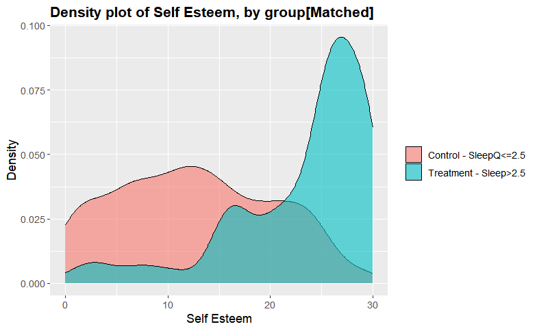

```r
ggplot(m_without_replacement_df, aes(x = m_without_replacement_df$self_esteem, fill = factor(m_without_replacement_df$sleep_quality_treatment))) + geom_density(position="identity", alpha=0.6) +
    scale_fill_brewer(palette="Dark2") + ggtitle("Density plot of Self Esteem, by group[Matched]") +
    scale_x_continuous(name = "Self Esteem") +
    scale_y_continuous(name = "Density") + theme(plot.title = element_text(size = 14, face =
                                                                               "bold"), text = element_text(size = 12)) + guides(fill=guide_legend(title=NULL))+
    scale_fill_discrete(labels=c("Control - SleepQ<=2.5", "Treatment - Sleep>2.5"))
```

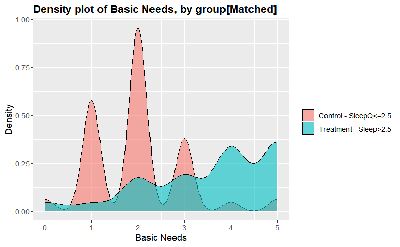

```r
ggplot(m_without_replacement_df, aes(x = m_without_replacement_df$basic_needs, fill = factor(m_without_replacement_df$sleep_quality_treatment))) + geom_density(position="identity", alpha=0.6) +
    scale_fill_brewer(palette="Dark2") + ggtitle("Density plot of Basic Needs, by group[Matched]") +
    scale_x_continuous(name = "Basic Needs") +
    scale_y_continuous(name = "Density") + theme(plot.title = element_text(size = 14, face =
                                                                               "bold"), text = element_text(size = 12)) + guides(fill=guide_legend(title=NULL))+
    scale_fill_discrete(labels=c("Control - SleepQ<=2.5", "Treatment - Sleep>2.5"))
```

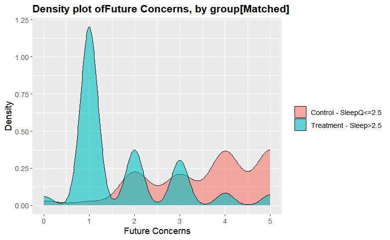

```r
ggplot(m_without_replacement_df, aes(x = m_without_replacement_df$future_career_concerns, fill = factor(m_without_replacement_df$sleep_quality_treatment))) + geom_density(position="identity", alpha=0.6) +
    scale_fill_brewer(palette="Dark2") + ggtitle("Density plot ofFuture Concerns, by group[Matched]") +
    scale_x_continuous(name = "Future Concerns") +
    scale_y_continuous(name = "Density") + theme(plot.title = element_text(size = 14, face =
                                                                               "bold"), text = element_text(size = 12)) + guides(fill=guide_legend(title=NULL))+
    scale_fill_discrete(labels=c("Control - SleepQ<=2.5", "Treatment - Sleep>2.5"))
```

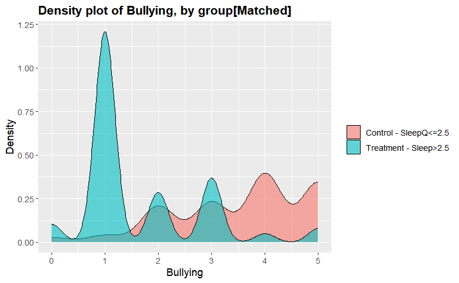

```r
ggplot(m_without_replacement_df, aes(x = m_without_replacement_df$bullying, fill = factor(m_without_replacement_df$sleep_quality_treatment))) + geom_density(position="identity", alpha=0.6) +
    scale_fill_brewer(palette="Dark2") + ggtitle("Density plot of Bullying, by group[Matched]") +
    scale_x_continuous(name = "Bullying") +
    scale_y_continuous(name = "Density") + theme(plot.title = element_text(size = 14, face =
                                                                               "bold"), text = element_text(size = 12)) + guides(fill=guide_legend(title=NULL))+
    scale_fill_discrete(labels=c("Control - SleepQ<=2.5", "Treatment - Sleep>2.5"))
```

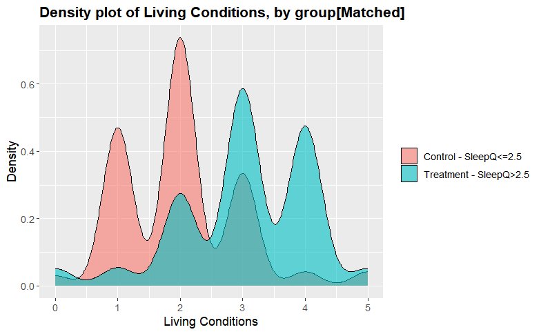

```r
ggplot(m_without_replacement_df, aes(x = m_without_replacement_df$living_conditions, fill = factor(m_without_replacement_df$sleep_quality_treatment))) + geom_density(position="identity", alpha=0.6) +
    scale_fill_brewer(palette="Dark2") + ggtitle("Density plot of Living Conditions, by group[Matched]") +
    scale_x_continuous(name = "Living Conditions") +
    scale_y_continuous(name = "Density") + theme(plot.title = element_text(size = 14, face =
                                                                               "bold"), text = element_text(size = 12)) + guides(fill=guide_legend(title=NULL))+
    scale_fill_discrete(labels=c("Control - SleepQ<=2.5", "Treatment - SleepQ>2.5"))
```

## 5.2 with replacement

### 5.2.1 t-tests:

1. Self Esteem:

```r
print(t.test(m_with_replacement_df$self_esteem[m_with_replacement_df$sleep_quality>2.5][1:137],m_with_replacement_df$self_esteem[m_with_replacement_df$sleep_quality<=2.5][1:137])$p.value)
```

```
[1] 2.625316e-08
```

2. Basic Needs:

```r
print(t.test(m_with_replacement_df$basic_needs[m_with_replacement_df$sleep_quality>2.5][1:137],m_with_replacement_df$basic_needs[m_with_replacement_df$sleep_quality<=2.5][1:137])$p.value)
```

```
[1] 1.46718e-11
```

3. Future Career Concerns:

```r
print(t.test(m_with_replacement_df$future_career_concerns[m_with_replacement_df$sleep_quality>2.5][1:137],m_with_replacement_df$future_career_concerns[m_with_replacement_df$sleep_quality<=2.5][1:137])$p.value)
```

```
[1] 1.933111e-10
```

4. BUllying:

```r
print(t.test(m_with_replacement_df$bullying[m_with_replacement_df$sleep_quality>2.5][1:137],m_with_replacement_df$bullying[m_with_replacement_df$sleep_quality<=2.5][1:137])$p.value)
```

```
[1] 1.115877e-14
```

5. Living Conditions

```r
print(t.test(m_with_replacement_df$living_conditions[m_with_replacement_df$sleep_quality>2.5][1:137],m_with_replacement_df$living_conditions[m_with_replacement_df$sleep_quality<=2.5][1:137])$p.value)
```

```
[1] 1.137508e-09
```

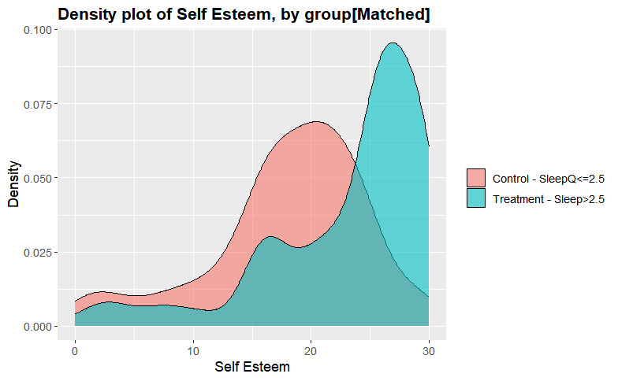

```r
ggplot(m_with_replacement_df, aes(x = m_with_replacement_df$self_esteem, fill = factor(m_with_replacement_df$sleep_quality_treatment))) + geom_density(position="identity", alpha=0.6) +
    scale_fill_brewer(palette="Dark2") + ggtitle("Density plot of Self Esteem, by group[Matched]") +
    scale_x_continuous(name = "Self Esteem") +
    scale_y_continuous(name = "Density") + theme(plot.title = element_text(size = 14, face =
                                                                               "bold"), text = element_text(size = 12)) + guides(fill=guide_legend(title=NULL))+
    scale_fill_discrete(labels=c("Control - SleepQ<=2.5", "Treatment - Sleep>2.5"))
```

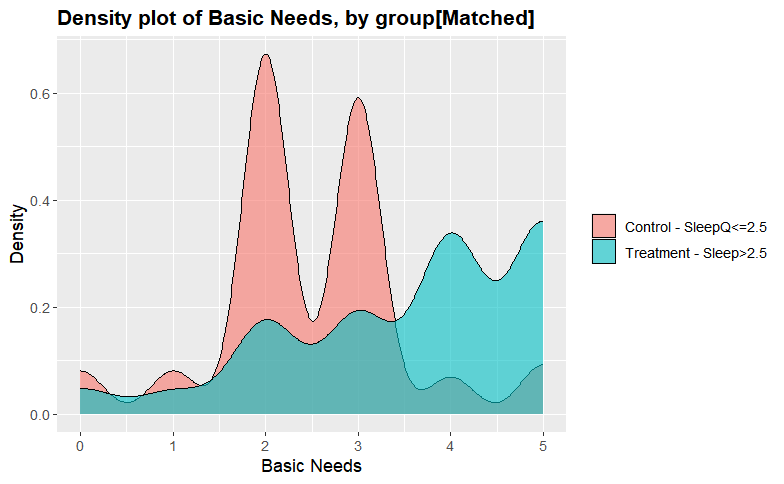

```r
ggplot(m_with_replacement_df, aes(x = m_with_replacement_df$basic_needs, fill = factor(m_with_replacement_df$sleep_quality_treatment))) + geom_density(position="identity", alpha=0.6) +
    scale_fill_brewer(palette="Dark2") + ggtitle("Density plot of Basic Needs, by group[Matched]") +
    scale_x_continuous(name = "Basic Needs") +
    scale_y_continuous(name = "Density") + theme(plot.title = element_text(size = 14, face =
                                                                               "bold"), text = element_text(size = 12)) + guides(fill=guide_legend(title=NULL))+
    scale_fill_discrete(labels=c("Control - SleepQ<=2.5", "Treatment - Sleep>2.5"))
```

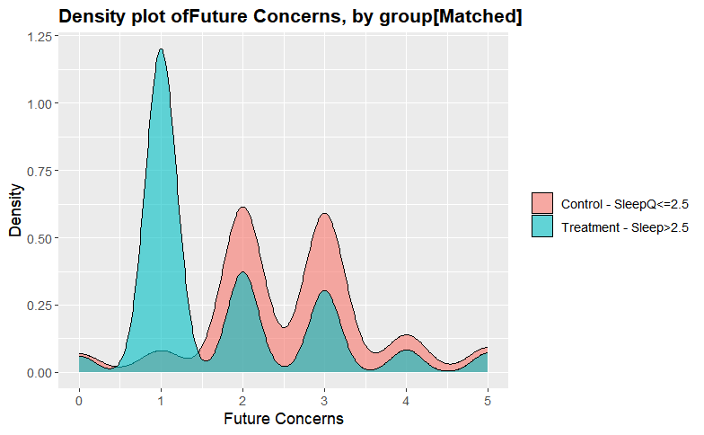

```r
ggplot(m_with_replacement_df, aes(x = m_with_replacement_df$future_career_concerns, fill = factor(m_with_replacement_df$sleep_quality_treatment))) + geom_density(position="identity", alpha=0.6) +
    scale_fill_brewer(palette="Dark2") + ggtitle("Density plot ofFuture Concerns, by group[Matched]") +
    scale_x_continuous(name = "Future Concerns") +
    scale_y_continuous(name = "Density") + theme(plot.title = element_text(size = 14, face =
                                                                               "bold"), text = element_text(size = 12)) + guides(fill=guide_legend(title=NULL))+
    scale_fill_discrete(labels=c("Control - SleepQ<=2.5", "Treatment - Sleep>2.5"))
```

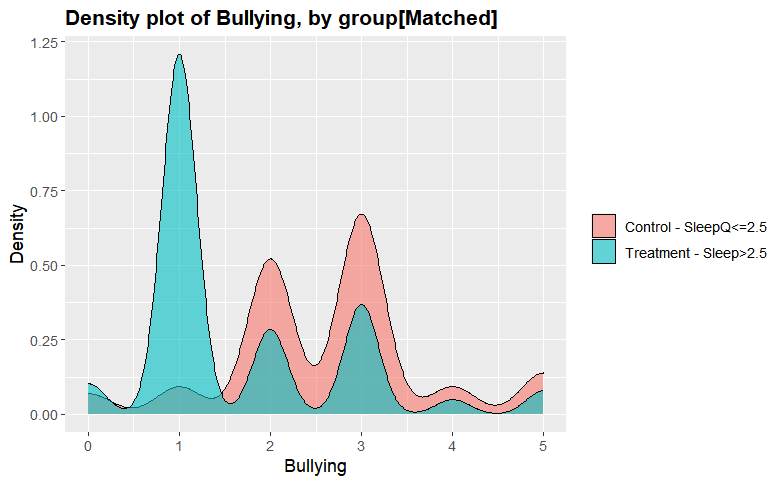

```r
ggplot(m_with_replacement_df, aes(x = m_with_replacement_df$bullying, fill = factor(m_with_replacement_df$sleep_quality_treatment))) + geom_density(position="identity", alpha=0.6) +
    scale_fill_brewer(palette="Dark2") + ggtitle("Density plot of Bullying, by group[Matched]") +
    scale_x_continuous(name = "Bullying") +
    scale_y_continuous(name = "Density") + theme(plot.title = element_text(size = 14, face =
                                                                               "bold"), text = element_text(size = 12)) + guides(fill=guide_legend(title=NULL))+
    scale_fill_discrete(labels=c("Control - SleepQ<=2.5", "Treatment - Sleep>2.5"))
```

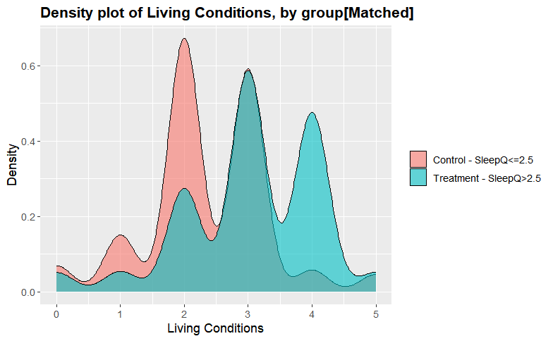

```r
ggplot(m_with_replacement_df, aes(x = m_with_replacement_df$living_conditions, fill = factor(m_with_replacement_df$sleep_quality_treatment))) + geom_density(position="identity", alpha=0.6) +
    scale_fill_brewer(palette="Dark2") + ggtitle("Density plot of Living Conditions, by group[Matched]") +
    scale_x_continuous(name = "Living Conditions") +
    scale_y_continuous(name = "Density") + theme(plot.title = element_text(size = 14, face =
                                                                               "bold"), text = element_text(size = 12)) + guides(fill=guide_legend(title=NULL))+
    scale_fill_discrete(labels=c("Control - SleepQ<=2.5", "Treatment - SleepQ>2.5"))
```

## 5.3 with caliper

### 5.3.1 t-tests:

1. Self Esteem:

```r
print(t.test(m_caliper_df$self_esteem[m_caliper_df$sleep_quality>2.5][1:137],m_caliper_df$self_esteem[m_caliper_df$sleep_quality<=2.5][1:137])$p.value)
```

```
[1] 2.625316e-08
```

2. Basic Needs:

```r
print(t.test(m_caliper_df$basic_needs[m_caliper_df$sleep_quality>2.5][1:137],m_caliper_df$basic_needs[m_caliper_df$sleep_quality<=2.5][1:137])$p.value)
```

```
[1] 1.46718e-11
```

3. Future Career Concerns:

```r
print(t.test(m_caliper_df$future_career_concerns[m_caliper_df$sleep_quality>2.5],m_caliper_df$future_career_concerns[m_caliper_df$sleep_quality<=2.5])$p.value)
```

```
[1] 1.446751e-15
```

4. BUllying:

```r
print(t.test(m_caliper_df$bullying[m_caliper_df$sleep_quality>2.5],m_caliper_df$bullying[m_caliper_df$sleep_quality<=2.5])$p.value)
```

```
[1] 2.351767e-17
```

5. Living Conditions

```r
print(t.test(m_caliper_df$living_conditions[m_caliper_df$sleep_quality>2.5],m_caliper_df$living_conditions[m_caliper_df$sleep_quality<=2.5])$p.value)
```

```
[1] 8.804419e-12
```

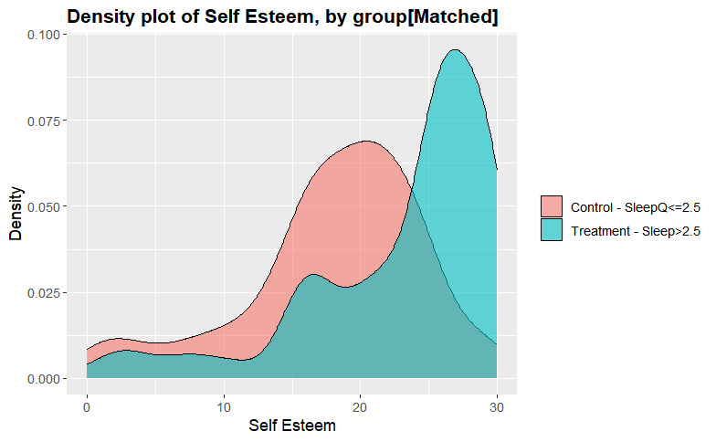

```r
ggplot(m_caliper_df, aes(x = m_caliper_df$self_esteem, fill = factor(m_caliper_df$sleep_quality_treatment))) + geom_density(position="identity", alpha=0.6) +
    scale_fill_brewer(palette="Dark2") + ggtitle("Density plot of Self Esteem, by group[Matched]") +
    scale_x_continuous(name = "Self Esteem") +
    scale_y_continuous(name = "Density") + theme(plot.title = element_text(size = 14, face =
                                                                               "bold"), text = element_text(size = 12)) + guides(fill=guide_legend(title=NULL))+
    scale_fill_discrete(labels=c("Control - SleepQ<=2.5", "Treatment - Sleep>2.5"))
```

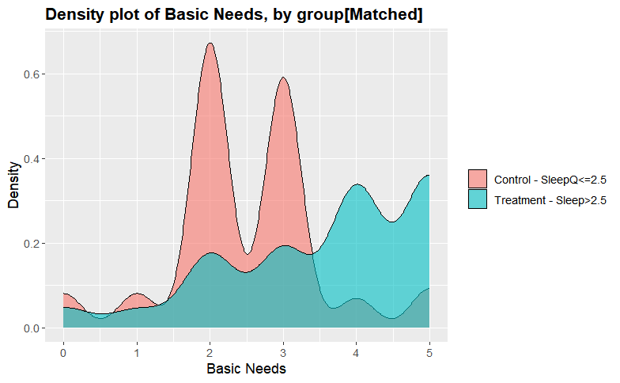

```r
ggplot(m_caliper_df, aes(x = m_caliper_df$basic_needs, fill = factor(m_caliper_df$sleep_quality_treatment))) + geom_density(position="identity", alpha=0.6) +
    scale_fill_brewer(palette="Dark2") + ggtitle("Density plot of Basic Needs, by group[Matched]") +
    scale_x_continuous(name = "Basic Needs") +
    scale_y_continuous(name = "Density") + theme(plot.title = element_text(size = 14, face =
                                                                               "bold"), text = element_text(size = 12)) + guides(fill=guide_legend(title=NULL))+
    scale_fill_discrete(labels=c("Control - SleepQ<=2.5", "Treatment - Sleep>2.5"))
```

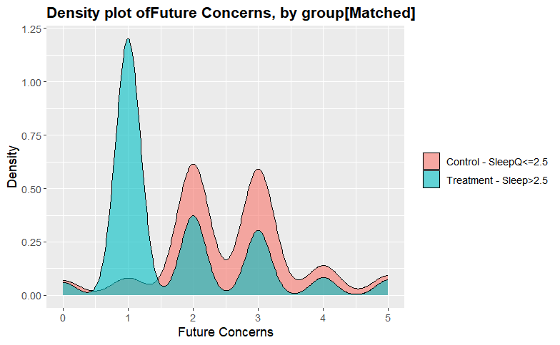

```r
ggplot(m_caliper_df, aes(x = m_caliper_df$future_career_concerns, fill = factor(m_caliper_df$sleep_quality_treatment))) + geom_density(position="identity", alpha=0.6) +
    scale_fill_brewer(palette="Dark2") + ggtitle("Density plot ofFuture Concerns, by group[Matched]") +
    scale_x_continuous(name = "Future Concerns") +
    scale_y_continuous(name = "Density") + theme(plot.title = element_text(size = 14, face =
                                                                               "bold"), text = element_text(size = 12)) + guides(fill=guide_legend(title=NULL))+
    scale_fill_discrete(labels=c("Control - SleepQ<=2.5", "Treatment - Sleep>2.5"))
```

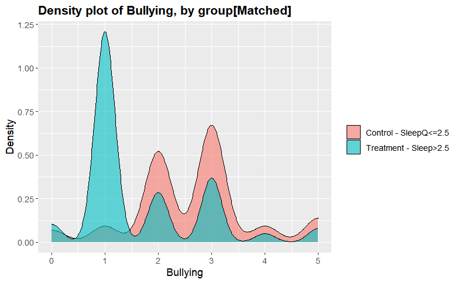

```r
ggplot(m_caliper_df, aes(x = m_caliper_df$bullying, fill = factor(m_caliper_df$sleep_quality_treatment))) + geom_density(position="identity", alpha=0.6) +
    scale_fill_brewer(palette="Dark2") + ggtitle("Density plot of Bullying, by group[Matched]") +
    scale_x_continuous(name = "Bullying") +
    scale_y_continuous(name = "Density") + theme(plot.title = element_text(size = 14, face =
                                                                               "bold"), text = element_text(size = 12)) + guides(fill=guide_legend(title=NULL))+
    scale_fill_discrete(labels=c("Control - SleepQ<=2.5", "Treatment - Sleep>2.5"))
```

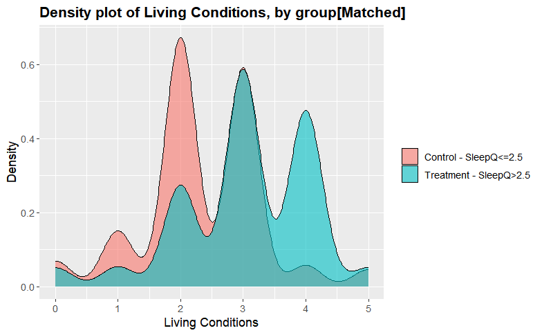

```r
ggplot(m_caliper_df, aes(x = m_caliper_df$living_conditions, fill = factor(m_caliper_df$sleep_quality_treatment))) + geom_density(position="identity", alpha=0.6) +
    scale_fill_brewer(palette="Dark2") + ggtitle("Density plot of Living Conditions, by group[Matched]") +
    scale_x_continuous(name = "Living Conditions") +
    scale_y_continuous(name = "Density") + theme(plot.title = element_text(size = 14, face =
                                                                               "bold"), text = element_text(size = 12)) + guides(fill=guide_legend(title=NULL))+
    scale_fill_discrete(labels=c("Control - SleepQ<=2.5", "Treatment - SleepQ>2.5"))
```